# NYC Flights Data Tranformation

Amruta Jadhav

##### Setup

In this problem set you will need the following R packages.

```r
# Load standard libraries
library(tidyverse)
library(nycflights13)
```

#### Problem 1: Describing the NYC Flights Data

In this problem set we will continue to use the data on all flights that departed NYC (i.e. JFK, LGA or EWR) in 2013. Recall, you can find this data in the `nycflights13` R package. Load the data in R and ensure you know the variables in the data. Keep the documentation of the dataset (e.g. the help file) nearby.

```r
#Loading data in R
data(flights)
flights
```

| year | month | day | dep_time | sched_dep_time | dep_delay | arr_time | sched_arr_time | arr_delay | carrier | flight | tailnum | origin | dest | air_time | distance | hour | minute | time_hour |
| --- | --- | --- | --- | --- | --- | --- | --- | --- | --- | --- | --- | --- | --- | --- | --- | --- | --- | --- |
| 2013 | 1 | 1 | 517 | 515 | 2 | 830 | 819 | 11 | UA | 1545 | N14228 | EWR | IAH | 227 | 1400 | 5 | 15 | 2013-01-01 05:00:00 |
| 2013 | 1 | 1 | 533 | 529 | 4 | 850 | 830 | 20 | UA | 1714 | N24211 | LGA | IAH | 227 | 1416 | 5 | 29 | 2013-01-01 05:00:00 |
| 2013 | 1 | 1 | 542 | 540 | 2 | 923 | 850 | 33 | AA | 1141 | N619AA | JFK | MIA | 160 | 1089 | 5 | 40 | 2013-01-01 05:00:00 |
| 2013 | 1 | 1 | 544 | 545 | -1 | 1004 | 1022 | -18 | B6 | 725 | N804JB | JFK | BQN | 183 | 1576 | 5 | 45 | 2013-01-01 05:00:00 |
| 2013 | 1 | 1 | 554 | 600 | -6 | 812 | 837 | -25 | DL | 461 | N668DN | LGA | ATL | 116 | 762 | 6 | 0 | 2013-01-01 06:00:00 |
| 2013 | 1 | 1 | 554 | 558 | -4 | 740 | 728 | 12 | UA | 1696 | N39463 | EWR | ORD | 150 | 719 | 5 | 58 | 2013-01-01 05:00:00 |
| 2013 | 1 | 1 | 555 | 600 | -5 | 913 | 854 | 19 | B6 | 507 | N516JB | EWR | FLL | 158 | 1065 | 6 | 0 | 2013-01-01 06:00:00 |
| 2013 | 1 | 1 | 557 | 600 | -3 | 709 | 723 | -14 | EV | 5708 | N829AS | LGA | IAD | 53 | 229 | 6 | 0 | 2013-01-01 06:00:00 |
| 2013 | 1 | 1 | 557 | 600 | -3 | 838 | 846 | -8 | B6 | 79 | N593JB | JFK | MCO | 140 | 944 | 6 | 0 | 2013-01-01 06:00:00 |
| 2013 | 1 | 1 | 558 | 600 | -2 | 753 | 745 | 8 | AA | 301 | N3ALAA | LGA | ORD | 138 | 733 | 6 | 0 | 2013-01-01 06:00:00 |

[output cut: 9990 more lines]

```r
colnames(flights)
```

```
##  [1] "year"           "month"          "day"            "dep_time"
##  [5] "sched_dep_time" "dep_delay"      "arr_time"       "sched_arr_time"
##  [9] "arr_delay"      "carrier"        "flight"         "tailnum"
## [13] "origin"         "dest"           "air_time"       "distance"
## [17] "hour"           "minute"         "time_hour"
```

In Problem Set 1 you started to explore this data. Now we will perform a more thorough description and summarization of the data, making use of our new data manipulation skills to answer a specific set of questions. When answering these questions be sure to include the code you used in computing empirical responses, this code should include code comments. Your response should also be accompanied by a written explanation, code alone is not a sufficient response.

##### (a) Describe and Summarize

Answer the following questions in order to describe and summarize the `flights` data.

1. How many flights out of NYC are there in the data?

There are total 336776 flights that have flown out of NYC in 2013

```r
# Selecting the 'flight' variable and then finding the total flights out of NYC

NYC_flights <- select(flights, flight)

nrow(NYC_flights)
```

```
## [1] 336776
```

2. How many NYC airports are included in this data? Which airports are these?

The NYC airports included in this data are EWR, JFK and LGA.

```r
#Using distinct verb

flights %>% distinct(origin)
```

| origin |
| --- |
| EWR |
| LGA |
| JFK |

3. Into how many airports did the airlines fly from NYC in 2013?

There are 105 destination airport in the dataset.

```r
flights %>% distinct(dest)
```

| dest |
| --- |
| IAH |
| MIA |
| BQN |
| ATL |
| ORD |
| FLL |
| IAD |
| MCO |
| PBI |
| TPA |

[output cut: 95 more lines]

There were total 3923 flights from NYC to Seattle.

```r
#Filtering flights to SEA and then counting the number
sea_flights <- filter(flights, dest == "SEA")

nrow(sea_flights)
```

```
## [1] 3923
```

5. Were the any flights from NYC to Spokane ?

There were no flights from NYC to Spokane in 2013.

```r
gag_flights <- filter(flights, dest == "GAG")

nrow(gag_flights)
```

```
## [1] 0
```

6. What about missing destination codes? Are there any destinations that do not look like valid airport codes (i.e. three-letter-all-upper case)?

**Hint**:check the function `grepl` to do regular expression matching. You may use `"^[[:upper:]]{3}$"` for a regular expression that matches three upper case letters. See an example below:

```
grepl("^[[:upper:]]{3}$", c("12AB", "SEA", "ABCD", "ATL"))

# [1] FALSE  TRUE FALSE  TRUE
```

As we can say from the output below, there are no invalid airport code in the dataset.

```r
grepl("^[[:upper:]]{3}$", unique(flights$dest))
```

```
##   [1] TRUE TRUE TRUE TRUE TRUE TRUE TRUE TRUE TRUE TRUE TRUE TRUE TRUE TRUE TRUE
##  [16] TRUE TRUE TRUE TRUE TRUE TRUE TRUE TRUE TRUE TRUE TRUE TRUE TRUE TRUE TRUE
##  [31] TRUE TRUE TRUE TRUE TRUE TRUE TRUE TRUE TRUE TRUE TRUE TRUE TRUE TRUE TRUE
##  [46] TRUE TRUE TRUE TRUE TRUE TRUE TRUE TRUE TRUE TRUE TRUE TRUE TRUE TRUE TRUE
##  [61] TRUE TRUE TRUE TRUE TRUE TRUE TRUE TRUE TRUE TRUE TRUE TRUE TRUE TRUE TRUE
##  [76] TRUE TRUE TRUE TRUE TRUE TRUE TRUE TRUE TRUE TRUE TRUE TRUE TRUE TRUE TRUE
##  [91] TRUE TRUE TRUE TRUE TRUE TRUE TRUE TRUE TRUE TRUE TRUE TRUE TRUE TRUE TRUE
```

##### (b) Reflect and Question

Comment on the questions (and answers) so far. Were you able to answer all of these questions? Are all questions well defined? Is the data good enough to answer all these?

Yes, I was able to answer all the questions. Yes, the questions are well-defined and dataset has all data needed to answer these questions.

#### Problem 2: NYC Flight Delays

Flights are often delayed. Let’s look closer at this topic using the NYC Flight dataset. Answer the following questions about flight delays using the `dplyr` data manipulation verbs we talked about in class.

##### (1) Typical Delays

What is the typical delay of flights in this data?

```r
# Finding typical departure delay
flights %>%  filter(dep_delay > 0) %>%
  arrange(desc(dep_delay)) %>%
  summarise(mean(dep_delay))
```

| mean(dep_delay) |
| --- |
| 39.37323 |

```r
# Finding typical arrival delay
flights %>% filter(arr_delay > 0) %>%
   arrange(desc(arr_delay)) %>%
   summarise(mean(arr_delay))
```

| mean(arr_delay) |
| --- |
| 40.3425 |

##### (2) Defining Flight Delays

What definition of flight delay did you use to answer part (a)? Did you do any specific exploration and description of this variable prior to using it? If no, please do so now. Is there any missing data? Are there any implausible or invalid entries?

I used the departure delay and arrival delay variables. Calculated the average delay of all the flights using “summarise” verb. For getting accurate results I filtered the missing entries and used delay observations greater than zero. I further investigated for the outliers, but there were no outliers and the data set has gradual increase in delay from 0 to 22 hours.

##### (3) Delays by Destination

Now compute flight delay by destinations. Which ones are the worst three destinations from NYC if you don’t like flight delays? Be sure to justify your delay variable choice.

From the exploration below we can see that airport TVC, TUL and BHM are the worst airports in terms of delays.

```r
flights %>% filter(arr_delay > 0) %>%
  group_by(dest) %>%
  summarise(mean_delay = mean(arr_delay)) %>%
  arrange(desc(mean_delay))
```

| dest | mean_delay |
| --- | --- |
| TVC | 66.68571 |
| TUL | 60.37306 |
| BHM | 60.05785 |
| TYS | 59.86645 |
| DSM | 57.02692 |
| OKC | 56.56219 |
| CAE | 53.63218 |
| RIC | 53.33027 |
| MSN | 52.77193 |
| CVG | 52.37917 |

[output cut: 93 more lines]

##### (4) Delays by time of day

We’d like to know how much do delays depend on the time of day. Are there more delays in the mornings? Late night when all the daily delays may accumulate? Create a visualization (graph or table) to illustrate your findings.

From table as well as the graphical visualization it is clear that there are more delays between 7 pm and 9 pm. Also, there is no data available for 1 am to 4am.

```r
delay_by_hour <-  flights %>% filter(dep_delay > 0) %>%
  group_by(hour) %>%
  summarise(hourly_delay = mean(dep_delay))
```

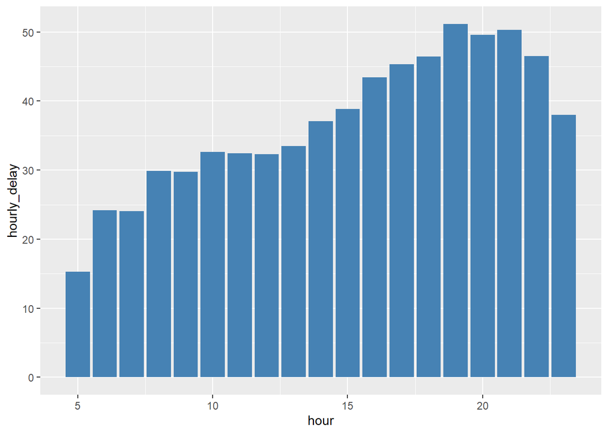

```r
# Plotting the graph by using delay_by_hour data
ggplot(delay_by_hour, aes(hour, hourly_delay)) +
  geom_col(fill = 'steelblue')
```

##### (5) Reflect and Challenge Your Results

After completing the exploratory analysis from Problem 2, do you have any concerns about these questions and your findings? How well defined were the questions? If you feel a question is not defined well enough, re-formulate it in a more specific way so you can actually answer this question. And state clearly what is your more precise question.  
Can you formulate any additional questions regarding flight delays?

I believe the the typical delay question is not well-defined. I have answered it by finding the mean of departure and arrival delay. But typical delays can be also be calculated by knowing the frequency by delay hours or minutes. I have provided the alternative way of finding typical delay below.

From the table below we can say that more than 24% flights have delay time between 0 and 1 hour. Frequency of flights having delay hours more than 9 hours are very low.

I believe all of the questions related to flight delays are formulated.

```r
# Finding typical departure delay
flights %>%  filter(dep_delay > 0) %>%
  mutate(delay_in_hours = round(dep_delay/60)) %>%
  group_by(delay_in_hours) %>%
  count(delay_in_hours)  %>%
  mutate(percent_flights = round(((n / 330000) * 100), 2))
```

| delay_in_hours | n | percent_flights |
| --- | --- | --- |
| 0 | 80141 | 24.29 |
| 1 | 32230 | 9.77 |
| 2 | 9885 | 3.00 |
| 3 | 3719 | 1.13 |
| 4 | 1473 | 0.45 |
| 5 | 597 | 0.18 |
| 6 | 232 | 0.07 |
| 7 | 75 | 0.02 |
| 8 | 28 | 0.01 |
| 9 | 6 | 0.00 |

[output cut: 10 more lines]

#### Problem 3: Let’s Fly Across the Country!

#### (a) Describe and Summarize

Answer the following questions in order to describe and summarize the `flights` data, focusing on flights from New York to Portland, OR (airport code `PDX`).

1. How many flights were there from NYC airports to Portland in 2013?

There were 1354 flights from NYC to Portland in 2013

```r
pdx_flights <- flights %>%
  filter(dest == "PDX")

nrow(pdx_flights)
```

```
## [1] 1354
```

2. How many airlines fly from NYC to Portland?

```r
n_distinct(pdx_flights$carrier)
```

```
## [1] 3
```

3. Which are these airlines (find the 2-letter abbreviations)? How many times did each of these go to Portland?

```r
unique(pdx_flights$carrier)
```

```
## [1] "DL" "UA" "B6"
```

```r
pdx_flights %>% count(carrier)
```

| carrier | n |
| --- | --- |
| B6 | 325 |
| DL | 458 |
| UA | 571 |

4. How many unique airplanes fly from NYC to PDX? \

```r
airplane_count <- pdx_flights %>% distinct(tailnum)

nrow(airplane_count)
```

```
## [1] 492
```

5. How many different airplanes arrived from each of the three NYC airports to Portland?

```r
pdx_flights %>%
  select(origin, tailnum) %>%
  distinct(tailnum, origin)  %>%
  count(origin)
```

| origin | n |
| --- | --- |
| EWR | 297 |
| JFK | 195 |

6. What percentage of flights to Portland were delayed at departure by more than 15 minutes?

```r
pdx_dep_delay <- pdx_flights %>% filter(dep_delay > 15)

percent_delay <- (nrow(pdx_dep_delay) / nrow(pdx_flights)) * 100

round(percent_delay)
```

```
## [1] 27
```

The mean departure delays from EWR and JFK airports are 33 and 37 minutes respectively. No one airport is noticebly worse than the other one.

```r
pdx_flights %>% select(origin, dep_delay) %>%
  filter(dep_delay > 0) %>%
  group_by(origin) %>%
  summarise(mean_by_origin = mean(dep_delay))
```

| origin | mean_by_origin |
| --- | --- |
| EWR | 33.23794 |
| JFK | 37.14865 |

#### (b) Reflect and Question

Comment on the questions (and answers) in this analysis. Were you able to answer all of these questions? Are all questions well defined? Is the data good enough to answer all these?

Yes, I was able to answer all the question and they were well-defined. Yes, the data is good enough to answer the questions.

#### Extra Credit

##### Seasonal Delays

Let’s get back to the question of flight delays. Flight delays may be partly related to weather, as you might have experienced for yourself. We do not have weather information here but let’s analyze how it is related to season. Which seasons have the worst flights delays? Why might this be the case? In your communication of your analysis use one graphical visualization and one tabular representation of your findings.

We can say by looking at the months that delays are more during the summer months. The reason for this might be that more people go on vacation in summers so more number of flights must be operating.

```r
# Creating a new dataframe 'df_delay' to find average delays by month

df_delay <- flights %>%
  select(dep_delay, month) %>%
  filter(dep_delay > 0) %>%
  na.omit()


# Average departure delay by month
dep_delay_bymonth <- df_delay %>%
  group_by(month) %>%
  summarize(avg_dep_delay = mean(dep_delay))
dep_delay_bymonth
```

| month | avg_dep_delay |
| --- | --- |
| 1 | 35.33533 |
| 2 | 35.29954 |
| 3 | 39.61638 |
| 4 | 44.18524 |
| 5 | 39.24515 |
| 6 | 49.79091 |
| 7 | 48.80782 |
| 8 | 37.27431 |
| 9 | 35.67678 |
| 10 | 31.56065 |

[output cut: 2 more lines]

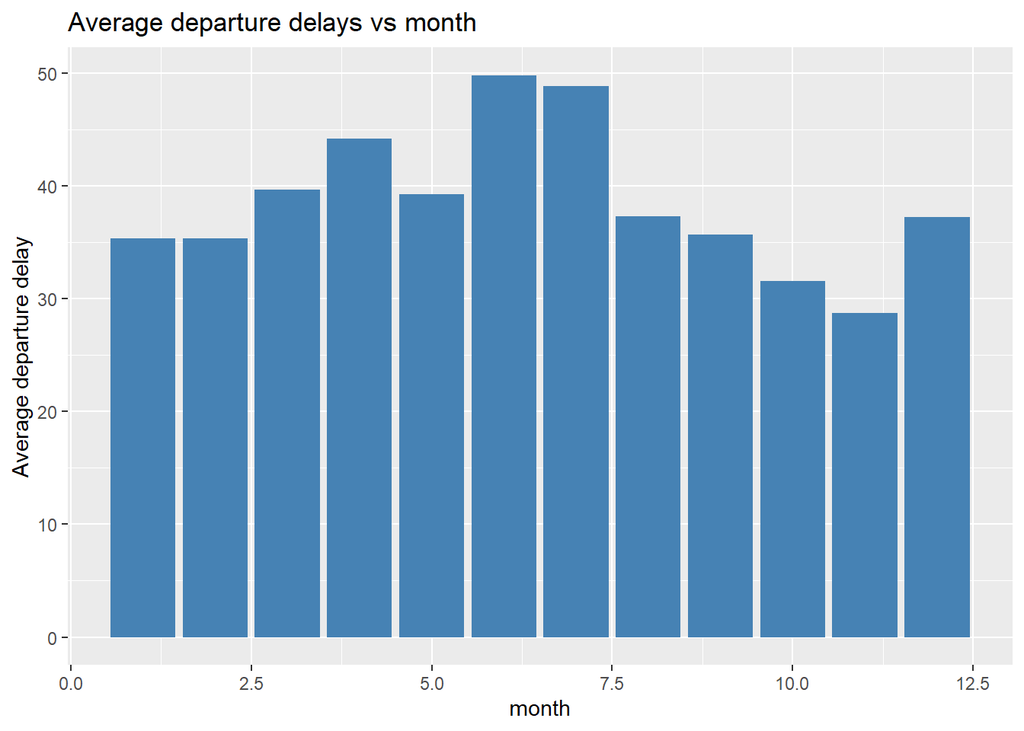

```r
# Plotting the average departure delay vs month graph

ggplot(data = dep_delay_bymonth,
        aes(x = month,
        y = avg_dep_delay)) +
        geom_col(fill = 'steelblue') +
        labs(title = "Average departure delays vs month",
        x = "month", y = "Average departure delay")
```

###### Refrences:

Stack Overflow - https://stackoverflow.com/

R cheatsheet - https://rstudio.com/resources/cheatsheets/